# RC subextraction in English: Experiment 2 notebook

Jake W. Vincent (jwvincen@ucsc.edu)

# 1 Motivation

Experiment 2 follows Experiment 1. Experiment 1 employed a length by complexity design (following Sprouse, Wagers, and Phillips (2013)), and a definiteness factor that manipulated the definiteness of a transitive object DP containing a Complex NP island. No effect of definiteness on transparency to extraction was found. Experiment 2 follows up on Experiment 1 by comparing RCs embedded inside subjects in derived positions (Spec, TP) to RCs inside subjects in non-derived positions (the pivot of an existential). Comparing DPs in these environments allows us to gauge the effect of presuppositionality on transparency to extraction, since DPs in the pivot of an existential are non-presupposed, while DPs in high subject position may be presupposed.

# 2 Design

1. **Factors**
   1. Subject
      1. there (low subject in pivot of existential)
      2. indefinite (high indefinite subject)
      3. definite (high definite subject)
   2. Dependency type
      1. anaphoric
      2. movement
2. **Sample item set**
   1. The president thinks that there are many Americans who supported him in the election living in rural areas.

      (there|anaphoric)
   2. The president is someone that there are many Americans who supported in the election living in rural areas.

      (there|movement)
   3. The president thinks that many Americans who supported him in the election are living in rural areas.

      (indefinite|anaphoric)
   4. The president is someone that many Americans who supported in the election are living in rural areas.

      (indefinite|movement)
   5. The president thinks that the Americans who supported him in the election are living in rural areas.

      (definite|anaphoric)
   6. The president is someone that the Americans who supported in the election are living in rural areas.

      (definite|movement)

# 3 Analysis

## 3.1 Version 1 (Lab)

The following code chunk reads in the data

```r
# Read in the data
raw_results_lab <- read.csv("results_all/csvFiles/20180320/expt_2_results_lab_long_20180320.csv")

# Rename 1st column name (excel issue)
colnames(raw_results_lab)[1] <- "timeReceived"

# Remove data for self-reported non-native English speakers (participants 104, 108, 114, 118, 124, 127, 130, 143)
raw_results_lab %>%
  subset(subject != 104) %>%
  subset(subject != 108) %>%
  subset(subject != 114) %>%
  subset(subject != 118) %>%
  subset(subject != 124) %>%
  subset(subject != 127) %>%
  subset(subject != 130) %>%
  subset(subject != 143) %>%
  droplevels -> raw_results_lab_native

# Extract experiment and filler data
raw_results_lab %>%
  subset(itemType == "experimental") %>%
  droplevels -> experiment_data_lab
raw_results_lab %>%
  subset(itemType == "filler") %>%
  droplevels -> filler_data_lab
```

The experiment results are presented in the following table by condition.

```r
# Make sure ratings data is numeric so that it can be averaged
experiment_data_lab$rating %<>% as.numeric

# Reverse levels of the intermSubj (subject) factor to mirror discussion
# Indefinite before Definite
experiment_data_lab$intermSubj <- relevel(experiment_data_lab$intermSubj, "indef")
# 'there' before indefinite and definite
experiment_data_lab$intermSubj <- relevel(experiment_data_lab$intermSubj, "there")


# Organize the data by condition
experiment_data_lab %>%
  group_by(intermSubj, dependencyType) %>%
  dplyr::summarize(mean_rating = mean(rating),
                   sd_rating = sd(rating),
                   n = n(),
                   se_rating = sd_rating/sqrt(n)) -> descriptive_summary_lab

# Save descriptive summary for use in other scripts
saveRDS(descriptive_summary_lab, file="expt2_descriptive_summary.rds")

# Print summary
print(descriptive_summary_lab)
```

| intermSubj | dependencyType | mean_rating | sd_rating | n | se_rating |
| --- | --- | --- | --- | --- | --- |
| there | coref | 3.633333 | 1.4489449 | 180 | 0.10799798 |
| there | move | 1.772222 | 0.9265214 | 180 | 0.06905883 |
| indef | coref | 4.738889 | 1.2388672 | 180 | 0.09233971 |
| indef | move | 1.977778 | 0.9742813 | 180 | 0.07261864 |
| def | coref | 4.888889 | 1.2185204 | 180 | 0.09082315 |
| def | move | 2.111111 | 1.1329937 | 180 | 0.08444836 |

The results are visualized in the plot generated by the following code chunk.

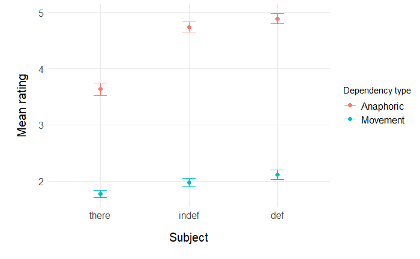

```r
descriptive_summary_lab %>%
  ggplot(aes(x = intermSubj,
             y = mean_rating,
             colour = dependencyType,
             group = dependencyType)) -> descriptive_plot_lab

descriptive_plot_lab +
  theme_minimal() +
  labs(x = "Subject",
       y = "Mean rating",
       colour = "Dependency type") +
  scale_color_discrete("Dependency type", labels = c("Anaphoric", "Movement")) +
  geom_errorbar(aes(ymin = mean_rating - se_rating,
                    ymax = mean_rating + se_rating),
                    width = 0.15) +
  geom_point(aes(col = dependencyType),
             size = 2) +
  scale_y_continuous(breaks = seq(1:6)) +
  theme(panel.grid.minor = element_blank(),
        legend.text = element_text(size = 12),
        axis.text = element_text(size = 12), # column labels
        axis.title.x = element_text(size = 15, # text of x-axis title (here, "Intermediate subject")
                                    margin = margin(0.5, NA, 0.5, NA, "cm")),
        axis.title.y = element_text(size = 15, # text of y-axis title (here, "Mean rating")
                                    margin = margin(NA, 0.5, NA, 0.5, "cm"))) -> descriptive_plot_lab
descriptive_plot_lab
```

The mean rating for the there|movement looks like it could be at floor here, so it would be good to look at the filler sentences that were expected to be ungrammatical and see if any of them were rated below this condition. The following code generates a plot in which the average rating for each filler sentences is represented as a thin orange line crossing the plot.

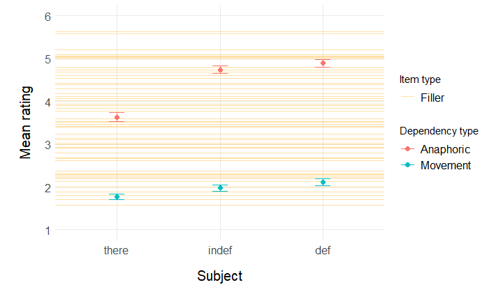

```r
descriptive_summary_lab %>%
  ggplot(aes(x = intermSubj,
             y = mean_rating,
             ymin = 1,
             ymax = 6,
             colour = dependencyType,
             group = dependencyType)) -> descriptive_plot_w_fillers

descriptive_plot_w_fillers +
  theme_minimal() +
  labs(x = "Subject",
       y = "Mean rating",
       colour = "Dependency type",
       linetype = "Item type") +
  scale_linetype_discrete(labels = "Filler") +
  scale_color_discrete(labels = c("Anaphoric", "Movement")) +
  geom_hline(data = descriptive_summary_lab_fillers,
             aes(yintercept = mean_rating,
                 linetype = itemType),
             color = "orange",
             alpha = 0.35,
             show.legend = TRUE) +
  geom_errorbar(aes(ymin = mean_rating - se_rating,
                    ymax = mean_rating + se_rating),
                    width = 0.15) +
  geom_point(aes(col = dependencyType),
             size = 2) +
  scale_y_continuous(breaks = seq(1:6)) +
  theme(panel.grid.minor = element_blank(),
        legend.text = element_text(size = 12),
        axis.text = element_text(size = 12), # column labels
        axis.title.x = element_text(size = 15, # text of x-axis title (here, "Intermediate subject")
                                    margin = margin(0.5, NA, 0.5, NA, "cm")),
        axis.title.y = element_text(size = 15, # text of y-axis title (here, "Mean rating")
                                    margin = margin(NA, 0.5, NA, 0.5, "cm"))) -> descriptive_plot_w_fillers
print(descriptive_plot_w_fillers)
```

## 3.2 Version 2 (Mechanical Turk)

Since the concern about a floor effect was not diffused by the ungrammatical filler sentences, a replicate version of this experiment was run on Mechanical Turk. The following code chunk reads in the second set of data.

```r
# Import the data
read.csv("results_all/csvFiles/20180306/expt_2_results_mturk_long_20180306.csv") -> raw_results_mturk

# Fix excel first col. name issue
colnames(raw_results_mturk)[1] <- "timeReceived"

# Separate fillers and experimental data
raw_results_mturk %>% subset(itemType == "experimental") %>% droplevels -> experiment_data_mturk
raw_results_mturk %>% subset(itemType == "filler") %>% droplevels -> filler_data_mturk
```

Participants were excluded whose average rating for ungrammatical filler sentences was higher than their average rating for grammatical filler sentences. This code chunk identifies participants who meet this criterion.

```r
filler_data_mturk %>%
  # Group filler data by subject
  group_by(subject) %>%
  # Average the ratings for each subject, including separate averages for expected grammatical and expected ungrammatical ratings
  summarize(mean_rating = mean(rating),
            sd_rating = sd(rating),
            n = n(),
            se_rating = sd_rating/sqrt(n),
            mean_gramm = mean(rating[expectedGramm == "1"]),
            mean_ungramm = mean(rating[expectedGramm == "0"])) -> worker_summary

# Find workers whose mean gramm is less than or equal to their mean ungramm
worker_summary %>%
  subset(mean_ungramm >= mean_gramm) %>%
  print
```

| subject | mean_rating | sd_rating | n | se_rating | mean_gramm | mean_ungramm |
| --- | --- | --- | --- | --- | --- | --- |

The average ratings for each condition are presented in the following table, and in the following plot, these ratings are plotted with the average rating for each filler sentence as above. The pattern of ratings was similar, although the experiment conditions were rated higher on average, and the filler sentences received a broader range of ratings.

```r
# Make sure ratings data is numeric
experiment_data_mturk$rating %<>% as.numeric

# Reverse levels of the intermSubj (subject) factor to mirror discussion
# Indefinite before Definite
experiment_data_mturk$intermSubj <- relevel(experiment_data_mturk$intermSubj, "indef")
# 'there' before indefinite and definite
experiment_data_mturk$intermSubj <- relevel(experiment_data_mturk$intermSubj, "there")

# Summarize the experimental data
experiment_data_mturk %>%
  group_by(intermSubj, dependencyType) %>%
  dplyr::summarize(meanRating = mean(rating),
                   sd.rating = sd(rating),
                   n = n(),
                   se.rating = sd.rating/sqrt(n)) -> descriptive_summary_mturk

# Summarize the filler data
filler_data_mturk %>% group_by(itemID,
                               expectedGramm,
                               itemType) %>%
  dplyr::summarize(mean_rating = mean(rating),
                   sd_rating = sd(rating),
                   n = n(),
                   se_rating = sd_rating/sqrt(n)) -> descriptive_summary_mturk_fillers

# Make a table
print(descriptive_summary_mturk)
```

| intermSubj | dependencyType | meanRating | sd.rating | n | se.rating |
| --- | --- | --- | --- | --- | --- |
| there | coref | 4.290541 | 1.252227 | 148 | 0.10293245 |
| there | move | 2.513514 | 1.406914 | 148 | 0.11564765 |
| indef | coref | 5.033784 | 1.151252 | 148 | 0.09463234 |
| indef | move | 2.716216 | 1.380331 | 148 | 0.11346250 |
| def | coref | 5.155405 | 1.079889 | 148 | 0.08876636 |
| def | move | 2.581081 | 1.272490 | 148 | 0.10459806 |

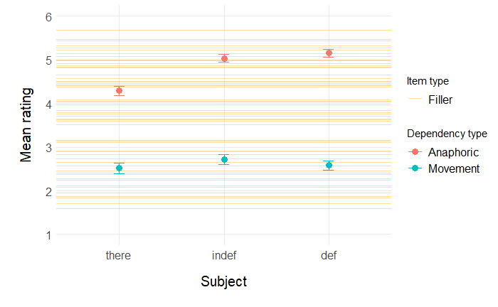

```r
# Same plot for Expt2 MTurk version w/ fillers overlaid
descriptive_summary_mturk %>%
  ggplot(aes(x = intermSubj,
             y = meanRating,
             ymin = 1,
             ymax = 6,
             colour = dependencyType,
             group = dependencyType)) -> descriptive_plot_fillers_mturk

descriptive_plot_fillers_mturk +
  theme_minimal() +
  labs(x = "Subject",
       y = "Mean rating",
       colour = "Dependency type",
       linetype = "Item type") +
  scale_linetype_discrete(labels = "Filler") +
  scale_color_discrete(labels = c("Anaphoric", "Movement")) +
  geom_hline(data = descriptive_summary_mturk_fillers,
             aes(yintercept = mean_rating,
                 linetype = itemType),
             color = "orange",
             alpha = 0.35,
             show.legend = TRUE) +
  geom_errorbar(aes(ymin = meanRating - se.rating,
                    ymax = meanRating + se.rating),
                width = 0.10) +
  geom_point(aes(col = dependencyType),
             size = 3) +
  scale_y_continuous(breaks = seq(1:6)) +
  theme(panel.grid.minor = element_blank(),
        legend.text = element_text(size = 12),
        axis.text = element_text(size = 12), # column labels
        axis.title.x = element_text(size = 15, # text of x-axis title (here, "Intermediate subject")
                                    margin = margin(0.5, NA, 0.5, NA, "cm")),
        axis.title.y = element_text(size = 15, # text of y-axis title (here, "Mean rating")
                                    margin = margin(NA, 0.5, NA, 0.5, "cm"))) -> descriptive_plot_fillers_mturk
descriptive_plot_fillers_mturk
```

## 3.3 Ordinal regression analysis

```r
# Make sure ratings data is a factor
experiment_data_mturk$rating %<>% as.factor

# Helmert contrast-coding
contrasts(experiment_data_mturk$intermSubj) <- "contr.helmert"

# Rename contrast column names
dimnames(contrasts(experiment_data_mturk$intermSubj))[[2]] <- c("definiteness", "height")

# Fix Helmert contrast coding so that in DEFINITENESS comparison, 'there' is neutralized, and in HEIGHT comparison, 'there' is compared to both def and indef
contrasts(experiment_data_mturk$intermSubj)[1,] <- c(0, 2)
contrasts(experiment_data_mturk$intermSubj)[2,] <- c(1, -1)
contrasts(experiment_data_mturk$intermSubj)[3,] <- c(-1, 1)

# Show contrasts for Subject factor
contrasts(experiment_data_mturk$intermSubj)
```

```
      definiteness height
there            0      2
indef            1     -1
def             -1      1
```

```r
# Set contrasts for dependency type & show
contrasts(experiment_data_mturk$dependencyType) <- c(-0.5, 0.5)

# Show contrasts for dependency type factor
contrasts(experiment_data_mturk$dependencyType)
```

```
      [,1]
coref -0.5
move   0.5
```

```r
# Save RDS file for use in other scripts
saveRDS(experiment_data_mturk, file = "expt2_data_mturk.rds")
```

The mixed effects ordinal regression analysis was run on the [UCSC hummingbird cluster](https://www.hb.ucsc.edu) as follows.

```r
# Full mixed effects analysis run on the hummingbird cluster as follows
# Read in the data saved from personal computer
readRDS(file = "expt2_data_mturk.rds") -> expt2_data

# Run ordinal regression analysis
clmm(data = expt2_data,
     # Rating as dependent variable, fixed effects as intermSubj, dependencyType, and their interactions
     formula = rating ~ intermSubj * dependencyType +
       # Random effects by subject
       (1 + intermSubj * dependencyType | subject) +
       # Random effects by item
       (1 + intermSubj * dependencyType | itemSet)
     ) -> expt2_clmm_full

# Save expt2_clmm_full
saveRDS(expt2_clmm_full, "expt2_clmm_full_20181118.rds")
```

```r
# Read in clmm data saved from cluster
readRDS("expt2_clmm_full_20181118.rds") -> expt2_clmm_cluster
summary(expt2_clmm_cluster)
```

```
Cumulative Link Mixed Model fitted with the Laplace approximation

formula: rating ~ intermSubj * dependencyType + (1 + intermSubj * dependencyType |
    subject) + (1 + intermSubj * dependencyType | itemSet)
data:    expt2_data
```

| link | threshold | nobs | logLik | AIC | niter | max.grad | cond.H |
| --- | --- | --- | --- | --- | --- | --- | --- |
| logit | flexible | 888 | -1181.93 | 2467.85 | 17901(106272) | 4.10e-02 | 1.6e+04 |

```
Random effects:
 Groups  Name                               Variance Std.Dev. Corr
 subject (Intercept)                        4.3385   2.0829
         intermSubjindef                    0.3675   0.6062   -0.774
         intermSubjthere                    2.2816   1.5105   -0.849  0.540
         dependencyTypemove                 6.9260   2.6317   -0.780  0.691  0.929
         intermSubjindef:dependencyTypemove 1.3518   1.1627    0.266 -0.134 -0.441 -0.502
         intermSubjthere:dependencyTypemove 4.7399   2.1771    0.459  0.007 -0.740 -0.600  0.781
 itemSet (Intercept)                        0.7054   0.8399
         intermSubjindef                    0.2425   0.4924    0.286
         intermSubjthere                    0.2896   0.5381   -0.128  0.914
         dependencyTypemove                 0.4536   0.6735   -0.935 -0.607 -0.232
         intermSubjindef:dependencyTypemove 0.3698   0.6081   -0.300 -1.000 -0.908  0.618
         intermSubjthere:dependencyTypemove 0.6563   0.8101    0.146 -0.906 -1.000  0.214  0.900
Number of groups:  subject 37,  itemSet 24

Coefficients:
                                       Estimate Std. Error z value Pr(>|z|)
intermSubjdefiniteness                 -0.03465    0.12163  -0.285    0.776
intermSubjheight                       -0.42393    0.07023  -6.037 1.57e-09 ***
dependencyType1                        -4.52988    0.46279  -9.788  < 2e-16 ***
intermSubjdefiniteness:dependencyType1  0.24417    0.23122   1.056    0.291
intermSubjheight:dependencyType1        0.62476    0.15586   4.008 6.11e-05 ***
---
Signif. codes:  0 ‘***’ 0.001 ‘**’ 0.01 ‘*’ 0.05 ‘.’ 0.1 ‘ ’ 1

Threshold coefficients:
    Estimate Std. Error z value
1|2  -4.0539     0.2898 -13.986
2|3  -1.9714     0.2581  -7.639
3|4  -0.6482     0.2511  -2.581
4|5   1.0279     0.2524   4.072
5|6   2.9003     0.2692  10.775
```

Sprouse, Jon, Matthew W. Wagers, and Colin Phillips. 2013. “Deriving competing predictions from grammatical approaches and reductionist approaches to island effects.” In *Experimental Syntax and Island Effects*, edited by Jon Sprouse and Norbert Hornstein, 21–41. Cambridge, United Kingdom: Cambridge University Press. https://doi.org/10.1017/CBO9781139035309.003.